# task6_done

```python
import numpy as np
import pandas as pd
import matplotlib.pyplot as plt
import seaborn as sns

sns.set(style='whitegrid', font_scale=1.3, palette='Set2')
%matplotlib inline
```

Будем также использовать `sklearn`.

```python
pd.options.mode.chained_assignment = None
from sklearn.model_selection import train_test_split
from sklearn.preprocessing import OneHotEncoder
from sklearn.linear_model import LinearRegression
from sklearn import metrics
```

### Задача 2.

Скоро лето — идеальное время года для путешествий и прогулок на велосипедах. В крупных городах обычно развиты сети проката велосипедов, предоставляющие удобный сервис. Одной из важных задач таких компаний является прогнозирование количества арендованных велосипедов в зависимости от времени года и погодных условий.

Рассмотрим датасет [Bike Sharing Dataset](https://archive.ics.uci.edu/ml/datasets/Bike+Sharing+Dataset) от компании [Capital Bikeshare](https://www.capitalbikeshare.com/), располагающей автоматизированными пунктами проката велосипедов. В датасете по дням записаны календарная информация и погодные условия, а также число прокатов в этот день. Цель — предсказать количество арендованных велосипедов по остальным характеристикам.

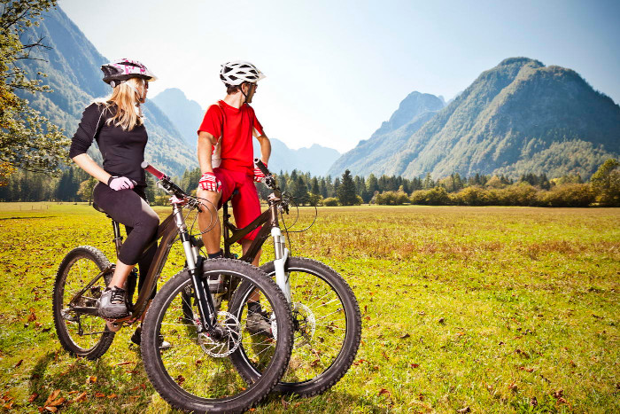

Будем работать только со следующими признаками:

- `season`: время года: 1 — зима, 2 — весна, 3 — лето, 4 — осень;
- `mnth`: месяц от 1 до 12;
- `holiday`: является ли текущий день праздничным;
- `weekday`: день недели от 0 до 6;
- `workingday`: является ли текущий день рабочим или выходным;
- `weathersit`: оценка благоприятности погоды от 1 (чистый, ясный день) до 4 (ливень, туман);
- `temp`: температура в Цельсиях;
- `atemp`: температура по ощущениям в Цельсиях;
- `hum`: влажность воздуха;
- `windspeed`: скорость ветра;
- `cnt`: количество арендованных велосипедов в текущий день.

Скачаем данные, загрузим их с помощью `pandas` и разделим на обучающую и тестовую части в соотношении 4:1. Далее всю аналитику необходимо проводить только на обучающей части данных.

```python
bike_data = pd.read_csv('bike_sharing_data.csv')
bike_data.drop(columns=['instant', 'yr', 'casual', 'registered'], inplace=True)
train, test = train_test_split(bike_data, test_size=0.2)
train.shape, test.shape
```

```
((584, 12), (147, 12))
```

#### 1. Визуальный анализ

Посмотрим по графикам, как *целевой признак зависит от остальных*. Строим графики.

```python
target_feature = 'cnt'
real_features = ['weekday', 'temp', 'atemp', 'hum', 'windspeed', 'season', 'mnth', 'weathersit']
categorial_features = ['holiday', 'workingday']
```

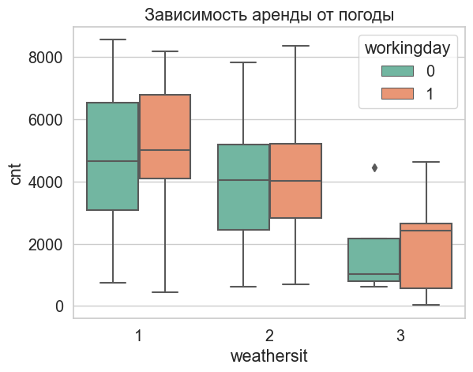

```python
sns.boxplot (
    data = train,
    x = 'weathersit',
    y = 'cnt',
    hue = 'workingday'
)
plt.title('Зависимость аренды от погоды')
```

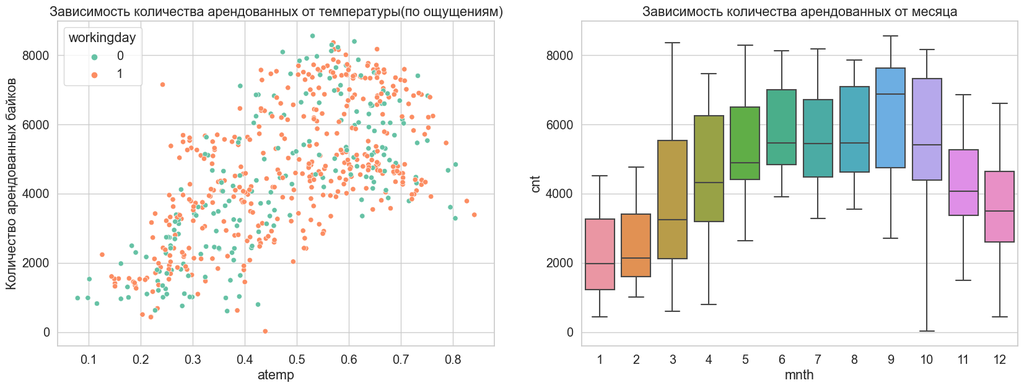

```python
fig, ax = plt.subplots(nrows = 1, ncols = 1, figsize=(20, 15))

plt.subplot(221)
plt.title('Зависимость количества арендованных от температуры(по ощущениям)')
plt.ylabel("Количество арендованных байков")

sns.scatterplot (
    data = train,
    x = 'atemp',
    y = 'cnt',
    hue = 'workingday'
)

plt.subplot(222)
plt.title('Зависимость количества арендованных от месяца')
plt.ylabel("Количество арендованных байков")
sns.boxplot(
    train,
    x = 'mnth',
    y = 'cnt')
```

Заметим, что минимум достягается в октябре, причем этот минимум очень сильно стремится к нулю. Рассмотрим эту ситуацию подробнее.

```python
train[(train.mnth == 10) & (train.cnt < 300)]
```

|  | dteday | season | mnth | holiday | weekday | workingday | weathersit | temp | atemp | hum | windspeed | cnt |
| --- | --- | --- | --- | --- | --- | --- | --- | --- | --- | --- | --- | --- |
| 667 | 2012-10-29 | 4 | 10 | 0 | 1 | 1 | 3 | 0.44 | 0.4394 | 0.88 | 0.3582 | 22 |

Также рассмотрим корреляцию у признаков

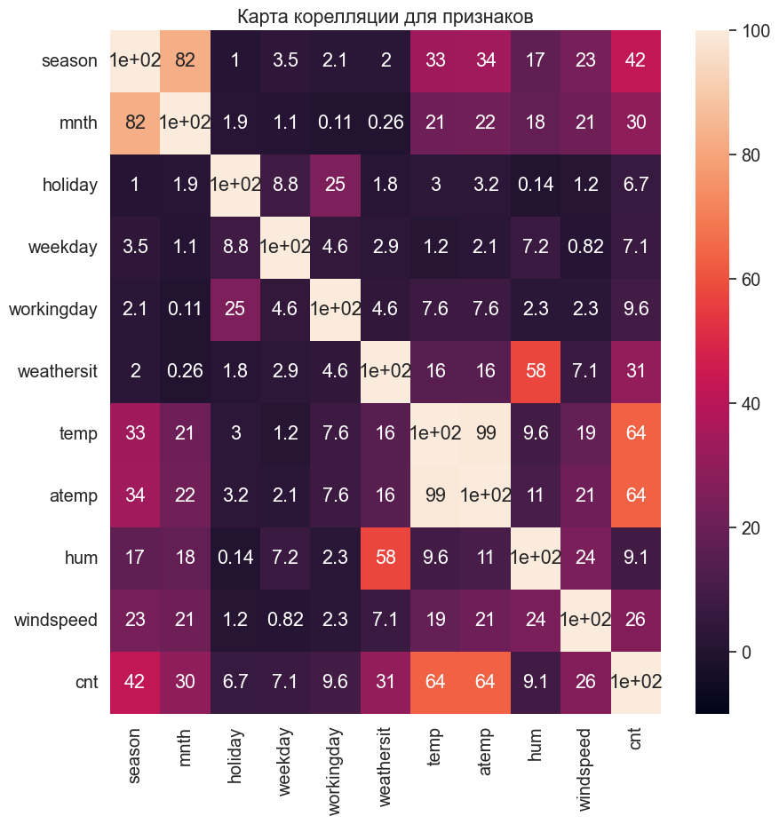

```python
fig, ax = plt.subplots(figsize=(10,10))
sns.heatmap (
    data = abs(train.drop(columns=['dteday']).corr()) * 100,
    annot = True,
    vmin = -10
)
plt.title('Карта корелляции для признаков')
```

Рассмотрим зависимости между temp и atemp, также рассмотрим ящики с усами чтобы отследить некоторые выбросы среди признаков

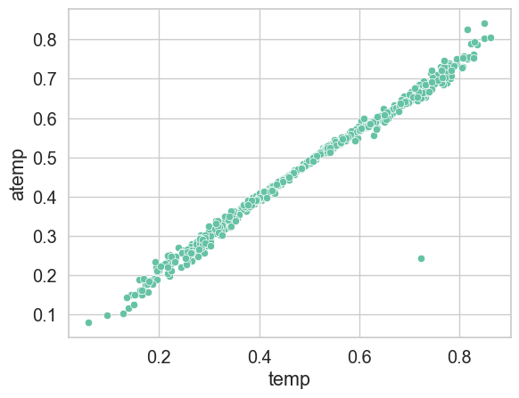

```python
sns.scatterplot(
    data = train,
    x = 'temp',
    y= 'atemp'
)
```

[output not shown]

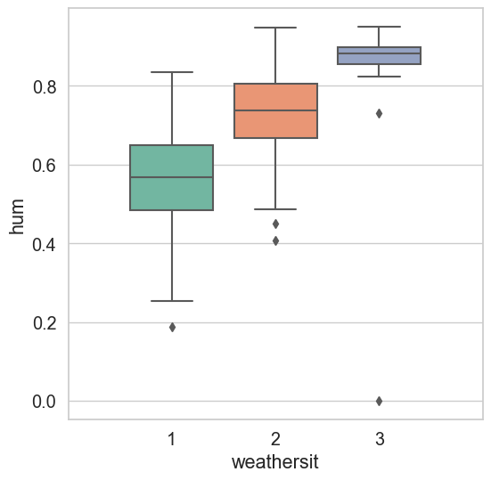

```python
fig, ax = plt.subplots(figsize=(6, 6))
sns.boxplot(
    data = train,
    x = 'weathersit',
    y= 'hum'
)
plt.xlim((-1, 3))
```

#### 2. Подготовка данных

**Процедура предобработки данных:**

**a).** Понятно, что оставлять сильно зависимые признаки в датасете для регрессионной модели невыгодно. Поэтому выкинем сначала temp, потом будем смотреть на остальные зависимости. Еще выкинем выбросы из выборки, их маленкькое количество

```python
try:
    train.drop(667, inplace=True)
except:
    test.drop(667, inplace=True)
def convert_data(data):
    """
    Функция, которая на вход получает датасет, убирает некоторые выброси в соответствии
    с выводами, сделанными выше, и возвращает готовый улучшенный датасет
    """
    data = data[abs(data.temp - data.atemp) <= 0.07] # Уберем температурные выбросы
    filtered_data = pd.DataFrame()
    filtered_data = pd.concat([filtered_data, data[(data.hum >= .32) & (data.weathersit==1)]])
    filtered_data = pd.concat([filtered_data, data[(data.hum >= .43) & (data.weathersit==2)]])
    filtered_data = pd.concat([filtered_data, data[(data.hum >= .8) & (data.weathersit==3)]])
    data = filtered_data.copy()
    data.drop(columns=['temp', 'mnth', 'hum'], inplace=True)
    return data

train = convert_data(train)
```

На данном этапе нам не поднадобится и dteday

```python
train.drop(columns=['dteday'], inplace=True)
```

#### 3. Обучение модели и ее анализ

Обучим линейную регрессию из `sklearn` на полученных данных и посмотрим на полученные оценки коэффициентов (в т.ч. свободный коэффициент).

```python
model = LinearRegression(fit_intercept=True)
model.fit(train.drop(columns=['cnt']), train['cnt'])
```

```
LinearRegression()
```

Посмотрим на оценку свободного коэффицента.

```python
model.intercept_
```

```
1660.185500519624
```

Теперь посмотрим оценку на остальные коэффиценты

```python
model.coef_
```

```
array([  415.51037189,  -440.51731897,    83.33222978,   203.71636627,
        -787.5930166 ,  6245.77488595, -1931.3180376 ])
```

Посчитаем ошибку предсказания на тестовой выборке по метрикам RMSE, MAE, MAPE.

```python
test.drop(columns=['temp', 'mnth'], inplace=True)
test.drop(columns=['hum'], inplace=True)
test.drop(columns=['dteday'], inplace=True)
predicts = model.predict(test.drop(columns=['cnt']))
```

```python
def mean_absolute_percentage_error(y_true, y_pred):
    return (100 * (np.abs(y_true - y_pred) / y_true)).mean()

RMSE = metrics.mean_squared_error(test['cnt'], predicts) ** 0.5
MAPE = mean_absolute_percentage_error(test['cnt'], predicts)
MAE = metrics.mean_absolute_error(test['cnt'], predicts)
RMSE, MAE, MAPE
```

```
(1359.4517700142753, 1151.3199149086017, 38.82540762530379)
```

Посчитаем оценку коэффициентов с помощью формулы. Не забываем про константный признак.

```python
X = train.drop(columns=['cnt'])
Y = train['cnt']

# Добавляем столбец единиц к матрице признаков, если хотим учитывать свободный коэффицент
X = np.hstack((np.ones((X.shape[0], 1)), X))

# Реализация формулы для оценки параметров модели
X_transpose = np.transpose(X)
X_transpose_X = np.matmul(X_transpose, X)
X_transpose_X_inv = np.linalg.inv(X_transpose_X)
X_transpose_Y = np.matmul(X_transpose, Y)

theta_hat = np.matmul(X_transpose_X_inv, X_transpose_Y)
```

```python
model.intercept_= theta_hat[0]
model.coef_ = theta_hat[1:]
second_predict = model.predict(test.drop(columns=['cnt']))
MAPE = mean_absolute_percentage_error(test['cnt'], second_predict)
MAPE
```

```
38.825407625303605
```

```python
np.linalg.det(X.T @ X)
```

```
1.0329591247541676e+16
```

Сделаем выводы.

**Выводы:**

1. Чего и стоило ожидать, встроенная функция LinearRegression обучается ровно так же, как и формула, выведенная явно на лекции.
2. Сильно коррелирующие (тобишь почти линейно-зависимые) признаки должны отсутствовать, так как в таком случае матрица $X^TX$ получается почти вырожденной, и $\theta$ либо очень тяжело считать, либо же его считать вообще невозможно, потому что детерминант матрицы будет равен нулю, что говорит нам о линейно зависимых столбцах.
3. Данные стоит хорошо прочистить от выбросов, так как некоторые выбросы очень сильно портят и обучение, и предикт. В данном примере у нас была строка с cnt=22, что является очень грубым выбросом для нашей выборки. И если его включать в тренирующую выборку, то мы получим плохую оценку коэффицентов, а если включать его в тестовую выборку, то у нас вообще некоторые метрики могут поломаться на этом. Пример – MAPE, который считает mean(). Если у нас где то будет cnt = 22 в правильных ответах, а наша модель будет предсказывать например 2200, так как остальные параметры на входе казалось бы являются благоприятными, то у нас получится $\frac{2200 - 22}{22}$, что определенно внесет огромную ошибку в нашу итоговую среднюю.

## Второй раздел

В данном разделе мы продолжим анализировать данные велопроката из задачи 2.

[figure not shown]

Для начала реализуем класс для работы с моделью ridge-регрессии, используя явную формулу. Интерфейс этого класса соответствует стандарту библиотеки `sklearn`, который использует также множество других библиотек.

```python
class RidgeRegression:
    def __init__(self, lambd=0.1, fit_intercept=True):
        '''
        Инициализация модели.
        Аргументы:
        lambd -- параметр регуляризации.
        fit_intercept -- добавить ли константный признак.
        '''
        self.lambd = lambd
        self.fit_intercept = fit_intercept

    def fit(self, X, Y):
        '''
        Обучение модели ridge-регрессии.
        Аргументы:
        X -- numpy-матрица объект-признак размера (n, d);
        Y -- numpy-вектор значений целевого признака размера (n,).
        '''

        if self.fit_intercept:
            X = np.hstack((np.ones((X.shape[0], 1)), X))

        mean = np.mean(X[:, 1:], axis=0)
        std = np.std(X[:, 1:], axis=0)
        X[:, 1:] = (X[:, 1:] - mean) / std

        n, d = X.shape
        I = np.eye(d)
        XTX = np.dot(X.T, X)
        XTY = np.dot(X.T, Y)

        self.result = np.linalg.inv(XTX + self.lambd * I).dot(XTY)
        self.intercept_ = self.result[0]
        self.coef_ = self.result[1:]


    def predict(self, X):
        '''
        Вычисление предсказаний.
        Аргументы:
        X -- numpy-матрица объект-признак размера (n, d);
        Возвращает:
        predictions -- предсказания в виде numpy-вектора размера (n,).
        '''
        if self.fit_intercept:
            X = np.hstack((np.ones((X.shape[0], 1)), X))

        n, d = X.shape
        if d != self.result.shape[0]:
            raise ValueError("Invalid shape of input matrix X")

        if self.fit_intercept:
            X[:, 1:] = (X[:, 1:] - np.mean(X[:, 1:], axis=0)) / np.std(X[:, 1:], axis=0)

        return np.dot(X, self.result)
```

Разделим данные на три части — обучающую, валидационную и тестовую в соотношении 3:1:1. На первой из них будем проводить всю аналитику и обучать все модели — регрессию, скалирование и т.д.. Вторую будем использовать для выбора оптимального значения гиперпараметра. Наконец, тестовую выборку необходимо использовать только для вычисления итогового значения метрик выбранной модели.

Сначала поделим данные на train и valid_test

```python
train, valid_test = train_test_split(bike_data, test_size=0.4)
test, valid = train_test_split(valid_test, test_size=0.5)
```

Теперь же поделим уже valid_test на valid и test соответственно.

```python
train.shape[0], test.shape[0], valid.shape[0]
```

[output not shown]

Выполним необходимые преобразования признаков.

```python
train = convert_data(train)
train.drop(columns=['dteday'], inplace=True)
```

Определим сетку значений гиперпараметра $\lambda$ и обучим для каждого значения сетки модель ridge-регрессии. Обычно эффективнее брать сетку в логарифмическом масштабе, воспользовавшись `np.logspace`.

```python
lambdas = np.logspace(-3, 3, num=100)
```

```python
test = convert_data(test)
test.drop(columns=['dteday'], inplace=True)

dic_valid = { 'lambda' : [], 'MAPE' : [], 'RMSE' : [], 'MAE' : []}
dic_test = { 'lambda' : [], 'MAPE' : [], 'RMSE' : [], 'MAE' : []}

def check_lambda():
    '''
    Функция, реализующая итерацию по лямбде (то есть подбор гиперпараметра)
    Итерируется по лямбде и заполняет соответствующие словари с метриками
    '''
    for i in lambdas:
        model = RidgeRegression(fit_intercept=True, lambd=i)
        model.fit(train.drop(columns=['cnt']), train['cnt'])
        predicted = model.predict(test.drop(columns=['cnt']))
        MAPE = mean_absolute_percentage_error(test['cnt'], predicted)
        MAE = metrics.mean_absolute_error(test['cnt'], predicted)
        RMSE = metrics.mean_squared_error(test['cnt'], predicted) ** .5
        dic_valid['lambda'].append(i)
        dic_valid['MAPE'].append(MAPE)
        dic_valid['RMSE'].append(RMSE)
        dic_valid['MAE'].append(MAE)
        dic_test['lambda'].append(i)
        dic_test['MAPE'].append(MAPE)
        dic_test['RMSE'].append(RMSE)
        dic_test['MAE'].append(MAE)

check_lambda()
results_valid = pd.DataFrame.from_dict(dic_valid)
results_test = pd.DataFrame.from_dict(dic_test)
```

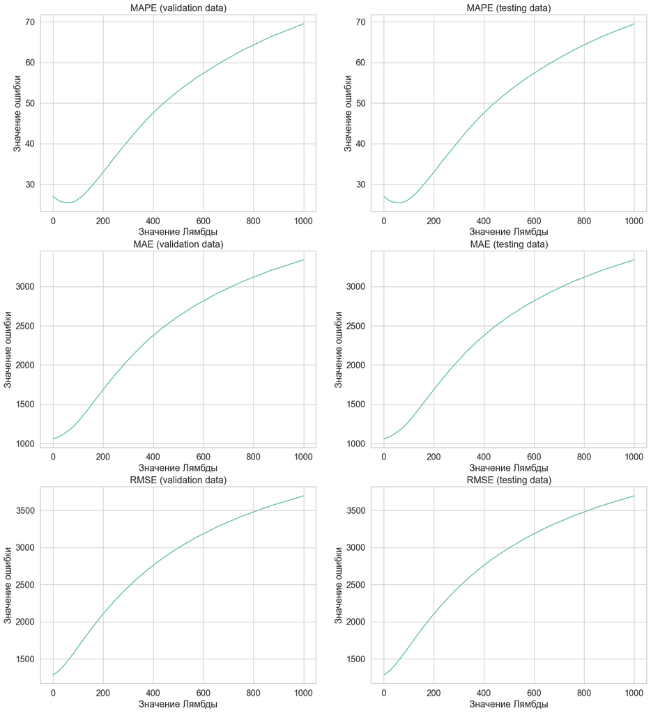

```python
fig, ax = plt.subplots(ncols = 2, nrows = 3, figsize=(18, 20))
metrics_list =['MAPE', 'MAE', 'RMSE']
for i in range(len(metrics_list)):
    ax[i, 0].plot(results_valid['lambda'], results_valid[metrics_list[i]])
    ax[i, 0].set_title(metrics_list[i] + ' (validation data)')
    ax[i, 0].set_ylabel('Значение ошибки')
    ax[i, 0].set_xlabel('Значение Лямбды')
    ax[i, 0].set_title(metrics_list[i] + ' (validation data)')
    ax[i, 1].plot(results_test['lambda'], results_test[metrics_list[i]])
    ax[i, 1].set_title(metrics_list[i] + ' (testing data)')
    ax[i, 1].set_ylabel('Значение ошибки')
    ax[i, 1].set_xlabel('Значение Лямбды')
```

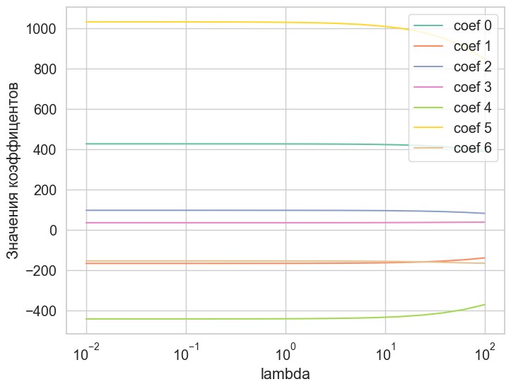

```python
lambda_values = np.logspace(-2, 2, num=20)

# Создаем пустой список для оценок коэффициентов
coef_values = []

# Обучаем модель ridge-регрессии для каждого значения гиперпараметра
for lambd in lambda_values:
    model = RidgeRegression(lambd=lambd, fit_intercept=True)
    model.fit(train.drop(columns=['cnt']), train['cnt'])
    coef_values.append(model.coef_)

# Преобразуем список коэффициентов в numpy-массив
coef_values = np.array(coef_values)

# Строим график зависимости коэффициентов от гиперпараметра
fig, ax = plt.subplots(figsize=(8, 6))
for i in range(coef_values.shape[1]):
    ax.plot(lambda_values, coef_values[:, i], label='coef {0}'.format(i))

ax.set_xscale('log')
ax.set_xlabel('lambda')
ax.set_ylabel('Значения коэффицентов')
ax.legend()
plt.show()
```

Зависимость является нелинейной и снижается по мере увеличения значения гиперпараметра. Это означает, что при больших значениях гиперпараметра модель становится менее чувствительной к данным.

Выберим оптимальное значение гиперпараметра и посчитайте ошибку на тестовой выборке.

```python
lambd = 102
model = RidgeRegression(fit_intercept=True, lambd=lambd)
model.fit(train.drop(columns=['cnt']), train['cnt'])
predicted = model.predict(test.drop(columns=['cnt']))
RMSE = metrics.mean_squared_error(test['cnt'], predicted) ** 0.5
MAPE = mean_absolute_percentage_error(test['cnt'], predicted)
MAE = metrics.mean_absolute_error(test['cnt'], predicted)
RMSE, MAE, MAPE
```

```
(1670.1874398984107, 1284.997392934581, 26.359402948201446)
```

Сделаем выводы.

### Раздел 3

Препдоложим, что у нас на входе очень больше данные

[figure not shown]

```python
coefs = 0
```

Реализуем процедуру стохастического градиентного спуска для поиска оценок коэффициентов в модели ridge-регрессии. Размер батча (набор объектов на каждой итерации) обычно берут кратно степени двойки, например, 128 или 256. Значение $\lambda$ можно взять из предыдущего раздела

```python
valid = convert_data(valid)
valid.drop(columns=['dteday'], inplace=True)
RMSE = metrics.mean_squared_error
MAE = metrics.mean_absolute_error
MAPE = metrics.mean_absolute_percentage_error
```

```python
def RidgeSGD(X, Y, X_val, Y_val, initial_coefs, batch_size, learning_rate, lambda_, num_epochs):
    """
    Функция которая реализует стахостический градиентный спуск для Ridge регрессии
    Аргументы:
    X, Y – соответственно признаки и целевой признак. (train data)
    X_val, Y_val – также, только валидационные
    batch_size – размер батча
    learning_rate – коэфицент обучения
    lambda_ – Смещение ridge регрессии
    num_epochs – количесто итерация (эпох)

    Возвращает:
    Оценку коэффицентов, также посчитанные метрики для разных эпох.

    """
    X = X.to_numpy()
    Y = Y.to_numpy()
    mean = np.mean(X[:, 1:], axis=0)
    std = np.std(X[:, 1:], axis=0)
    X[:, 1:] = (X[:, 1:] - mean) / std
    coefs = initial_coefs
    n_samples, n_features = X.shape
    train_metrics, val_metrics = [], []


    for epoch in range(num_epochs):
        idx = np.random.permutation(n_samples)
        X_shuffled = X[idx]
        Y_shuffled = Y[idx]

        for batch_start in range(0, n_samples, batch_size):
            batch_end = batch_start + batch_size
            X_batch = X_shuffled[batch_start:batch_end]
            Y_batch = Y_shuffled[batch_start:batch_end]

            Y_batch_pred = X_batch.dot(coefs)
            gradient = -2 * X_batch.T.dot(Y_batch - Y_batch_pred) / batch_size + 2 * lambda_ * coefs

            coefs -= learning_rate * gradient

        Y_train_pred = X.dot(coefs)
        Y_val_pred = X_val.dot(coefs)

        train_metrics.append([RMSE(Y, Y_train_pred) ** .5, MAE(Y, Y_train_pred), MAPE(Y, Y_train_pred)])
        val_metrics.append([RMSE(Y_val, Y_val_pred) ** .5, MAE(Y_val, Y_val_pred), MAPE(Y_val, Y_val_pred)])

    return coefs, np.array(train_metrics), np.array(val_metrics)
```

```python
initial_coefs = np.zeros(X.shape[1] - 1)
batch_size = 128
learning_rate = .0093
lambda_ = 1
num_epochs = 100

# Обучение модели
coefs, train_metrics, val_metrics = RidgeSGD(
    train.drop(columns=['cnt']),
    train['cnt'],
    valid.drop(columns=['cnt']),
    valid['cnt'],
    initial_coefs,
    batch_size,
    learning_rate,
    lambda_,
    num_epochs
)
```

Нарисуем графики зависимости значений метрик RMSE, MAE, MAPE от номера итерации для обучающей и валидационной выборок.

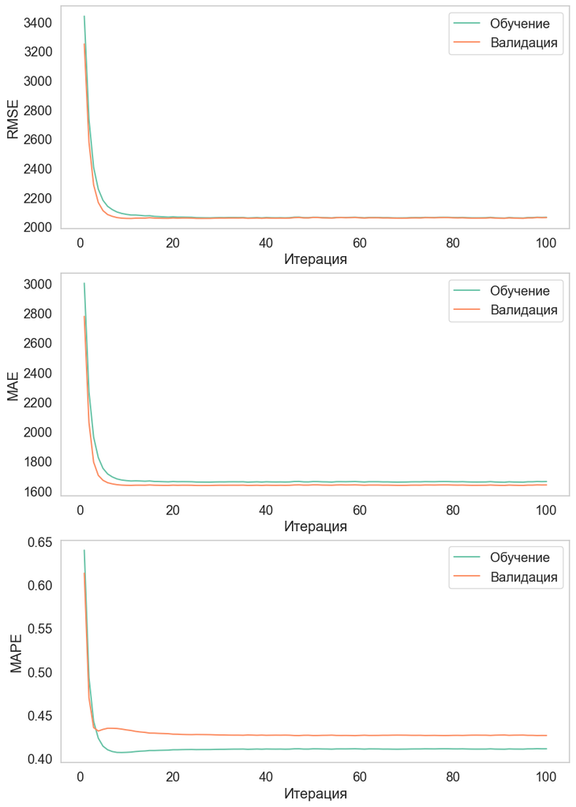

```python
fig, ax = plt.subplots(3, 1, figsize=(10, 15))

metric_names = ['RMSE', 'MAE', 'MAPE']
for i, metric_name in enumerate(metric_names):
    ax[i].plot(range(1, num_epochs + 1), train_metrics[:, i], label='Обучение')
    ax[i].plot(range(1, num_epochs + 1), val_metrics[:, i], label='Валидация')
    ax[i].set_xlabel('Итерация')
    ax[i].set_ylabel(metric_name)
    ax[i].legend()
    ax[i].grid()
```

Посчитаем ошибку на тестовой выборке.

```python
y_test_pred = test.drop(columns=['cnt']).dot(coefs)
y_test = test['cnt']

test_rmse = RMSE(y_test, y_test_pred)
test_mae = MAE(y_test, y_test_pred)
test_mape = MAPE(y_test, y_test_pred)

print('RMSE: ', test_rmse ** .5)
print('MAE: ', test_mae)
print('MAPE :', test_mape)
```

```
RMSE:  2336.011014452855
MAE:  1811.6854469651992
MAPE : 0.2971600180226114
```